# PracticalMachineLearningProject

Eduardo Sequeira

12/08/2020

# Coursera Practical Machine Learning Course Project

## Synopsis

The goal of this project is to predict the way of performing dumbbell biceps curls based on data from accelerometers located on the belt, forearm, arm, and dumbell of 6 participants. The 5 possible methods are: A: exactly according to the specification B: throwing the elbows to the front C: lifting the dumbbell only halfway D: lowering the dumbbell only halfway E: throwing the hips to the front

```r
knitr::opts_chunk$set(echo = TRUE)
```

## Initialization

```r
rm(list = ls(all = TRUE))

setwd('/Users/Eduardo/Documents/Coursera Directories/PracticalMachineLearning/Practical_Machine_Learning')

library(caret)
```

```r
library(ggplot2)

trainingRaw <- read.csv(file="pml-training.csv", header=TRUE, as.is = TRUE
                        , stringsAsFactors = FALSE, sep=','
                        ,na.strings=c('NA','','#DIV/0!'))

testingRaw <- read.csv(file="pml-testing.csv", header=TRUE, as.is = TRUE
                       , stringsAsFactors = FALSE, sep=','
                       , na.strings=c('NA','','#DIV/0!'))

trainingRaw$classe <- as.factor(trainingRaw$classe)
```

## Data Examination

With the data now unpacked and in R, we are able to look into the testingRaw data and the trainingRaw data, where we can look into the variables and observations avaliable to us. We will see variables such as: user names, the accelerometer data from the belt, forearm, arm, etc., as well as data from the dumbbell itself.

## Data Cleaning

Upon examing the data, we see immediately that there are a lot of NA values in this dataset, so to disregard the empty cells, and the NAs, we will do some data cleaning before continuing.

```r
indColToRemove <- which(colSums(is.na(trainingRaw) |trainingRaw=="")>0.9*dim(trainingRaw)[1])
TrainDataClean <- trainingRaw[,-indColToRemove]
TrainDataClean <- TrainDataClean[,-c(1:7)]

indColToRemove <- which(colSums(is.na(testingRaw) |testingRaw=="")>0.9*dim(testingRaw)[1])
TestDataClean <- testingRaw[,-indColToRemove]
TestDataClean <- TestDataClean[,-1]
```

## Cross Validation Set

Training set data has two portions - one for training, and one for testing.

```r
set.seed(12031987) # For Reproducible Research
inTrain = createDataPartition(TrainDataClean$classe, p = 3/4, list=FALSE)
training = TrainDataClean[inTrain,]
Test1 = TrainDataClean[-inTrain,]
```

## Training Model

```r
trControl <- trainControl(method="cv", number=5)
model_CT <- train(classe~., data=training, method="rpart", trControl=trControl)
```

## Training Set

```r
trainingPred <- predict(model_CT,newdata=training)
confMatrixCT <- confusionMatrix(training$classe, trainingPred)

confMatrixCT$table
```

```
##           Reference
## Prediction    A    B    C    D    E
##          A 3097  480  597    0   11
##          B 1113 1252  483    0    0
##          C  267  254 2046    0    0
##          D  669  477 1266    0    0
##          E  154  749  585    0 1218
```

```r
confMatrixCT$overall[1]
```

```
##  Accuracy
## 0.5172578
```

The accuracy of this model is quite poor, just barely surpassing 50%, which means that the predictions from this model will not be very well.

## Training Set with Gradient Boosting

```r
model_GBM <- train(classe~., data=training, method="gbm", trControl=trControl, verbose=FALSE)

print(model_GBM)
```

```
## Stochastic Gradient Boosting
##
## 14718 samples
##    52 predictor
##     5 classes: 'A', 'B', 'C', 'D', 'E'
##
## No pre-processing
## Resampling: Cross-Validated (5 fold)
## Summary of sample sizes: 11774, 11775, 11775, 11774, 11774
## Resampling results across tuning parameters:
##
##   interaction.depth  n.trees  Accuracy   Kappa
##   1                   50      0.7524800  0.6860833
##   1                  100      0.8216465  0.7741533
##   1                  150      0.8522890  0.8130536
##   2                   50      0.8579284  0.8199792
##   2                  100      0.9064408  0.8815910
##   2                  150      0.9311724  0.9129100
##   3                   50      0.8965210  0.8690244
##   3                  100      0.9448294  0.9301982
##   3                  150      0.9623588  0.9523796
##
## Tuning parameter 'shrinkage' was held constant at a value of 0.1
##
## Tuning parameter 'n.minobsinnode' was held constant at a value of 10
## Accuracy was used to select the optimal model using the largest value.
## The final values used for the model were n.trees = 150, interaction.depth =
##  3, shrinkage = 0.1 and n.minobsinnode = 10.
```

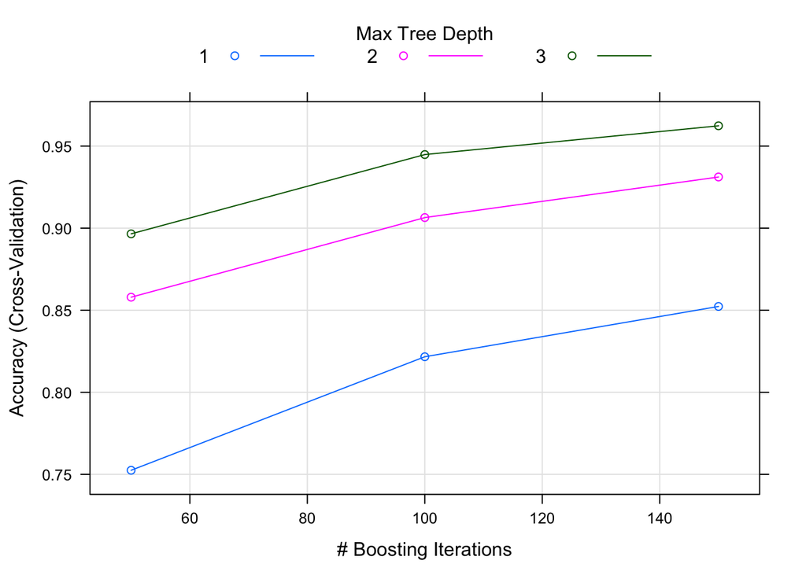

```r
plot(model_GBM)
```

```r
trainpred <- predict(model_GBM,newdata=Test1)

confMatGBM <- confusionMatrix(Test1$classe,trainpred)

confMatGBM$table
```

```
##           Reference
## Prediction    A    B    C    D    E
##          A 1374   14    2    4    1
##          B   23  888   33    5    0
##          C    0   30  814   10    1
##          D    0    7   25  767    5
##          E    1   12    8   12  868
```

```r
confMatGBM$overall[1]
```

```
##  Accuracy
## 0.9606444
```

The overall accuracy of the gbm model is much better than the previous, with an accuracy of 96% as opposed to roughly 50%. So, we will use this model to do our prediction.

Note: The Random Forest model could more easily provide a better prediction, but due to limitations and time constraints, previous attempts having gone for more than an hour processign with no results, this model is only recognized, but not run for this project…

```r
FinalTestPred <- predict(model_GBM,newdata=TestDataClean)
FinalTestPred
```

```
##  [1] B A B A A E D B A A B C B A E E A B B B
## Levels: A B C D E
```